# Compte-Rendu Atelier Statistique

#### Effet seance

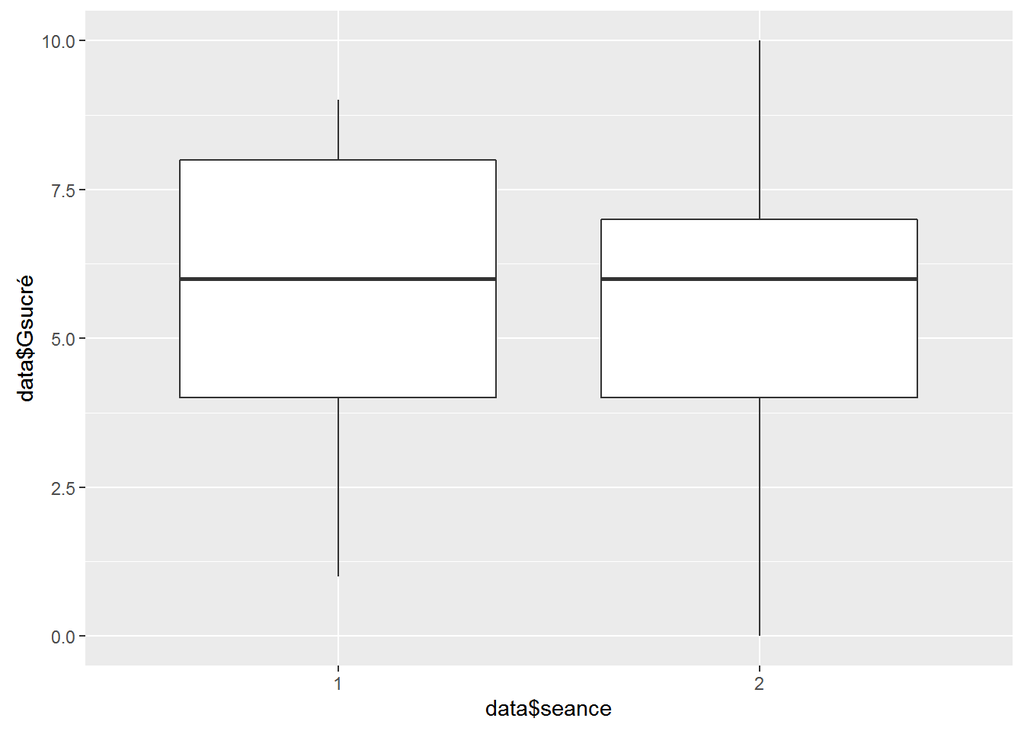

```r
l<-ggplot(data, aes(x=data$seance, y=data$Gsucré))
l1=l+geom_boxplot()
l1
```

Effet seance : On mesure, grâce à l’effet séance, la répétabilité des juges entre les deux, on remarque ici que cet effet ne l’emporte pas.

On fait appel ici au package “gridExtra” pour utiliser la commande grid.arrange qui nous permet de mettre les quatre plots sur un même graphique afin de faciliter la comréhension des graphes.

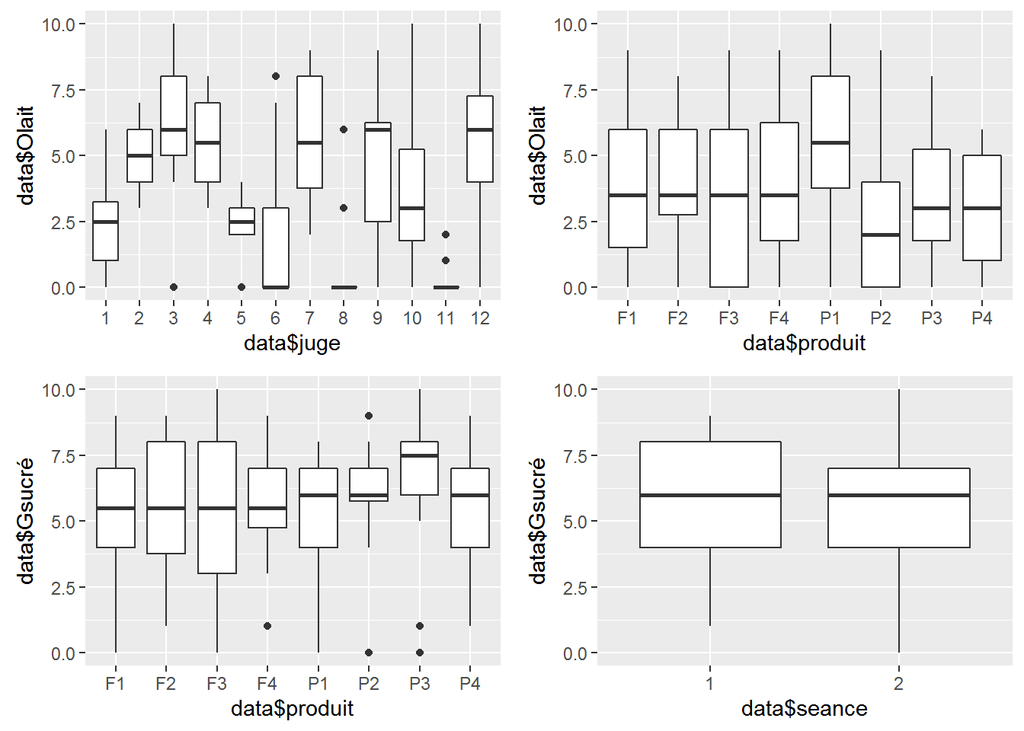

```r
library(gridExtra)
grid.arrange(p1,q1,k1,l1)
```

Pour le reste du notre travail,nous allons nous concentrer sur l’étude de l’effet produit . On distingue alors quatres tables selon les senses.

#### 1.La vision

```r
library(reshape2)
data.long1=melt(data[,-c(1)],c("juge","produit"),measure.vars=(3:4))
```

#### 2.L’odorat

```r
data.long2=melt(data[,-c(1)],c("juge","produit"),measure.vars=(5:10))
```

#### 3.Le toucher

```r
data.long3=melt(data[,-c(1)],c("juge","produit"),measure.vars=(11:17))
```

#### 4.Le gout

```r
data.long4=melt(data[,-c(1)],c("juge","produit"),measure.vars=(18:25))
```